# Relationships and multivariate methods

Block 5 · exercises 6 – 9

Sensometrics in R · SaIT

## Correlation: direction and strength

```r
set.seed(3); x <- rnorm(40)
par(mfrow = c(1, 3))
for (k in list(c(0.9, 0.4), c(0, 1), c(-0.8, 0.55))) {
  y <- k[1] * x + rnorm(40) * k[2]
  plot(x, y, pch = 19, col = pal[3], main = paste("r =", round(cor(x, y), 2)), xlab = "", ylab = "")
}
```

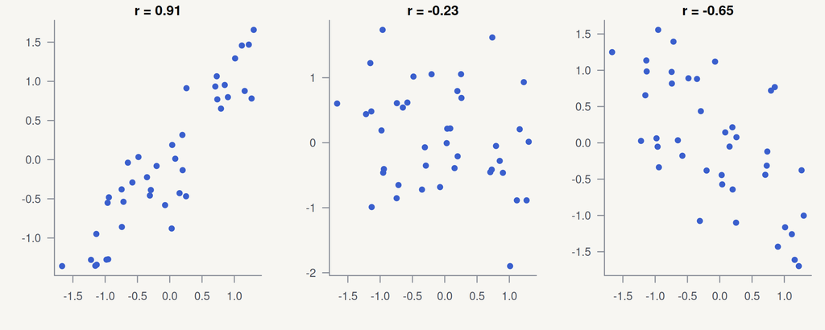

Pearson – a linear relationship. **Spearman** – a monotonic relationship on ranks (suitable for sensory scales).

## Correlation is not everything

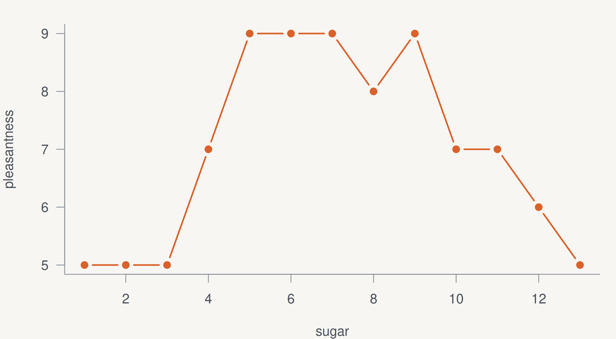

```r
sugar <- 1:13
pleasantness <- c(5, 5, 5, 7, 9, 9, 9, 8, 9, 7, 7, 6, 5)
plot(sugar, pleasantness, type = "b", pch = 19,
     col = pal[2], lwd = 2)
```

```r
cor(sugar, pleasantness, method = "spearman")
```

```
[1] 0.1591834
```

The correlation is almost zero although the relationship is strong – it has an **optimum**. Always plot first.

## Simple linear regression

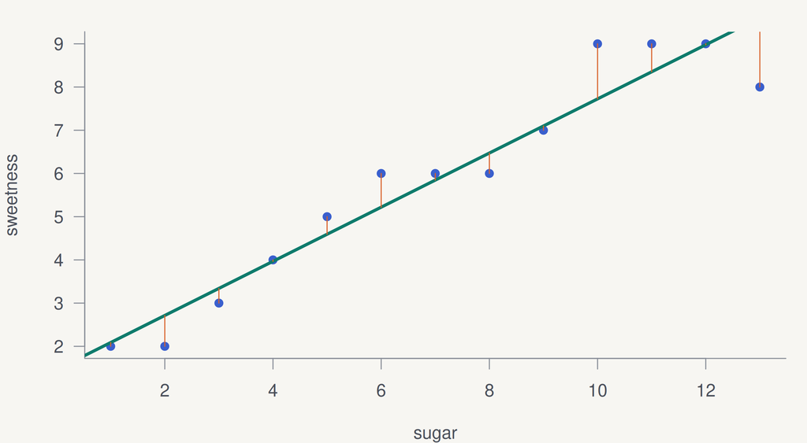

```r
sweetness <- c(2, 2, 3, 4, 5, 6, 6, 6, 7, 9, 9, 9, 8)
model <- lm(sweetness ~ sugar)
plot(sugar, sweetness, pch = 19, col = pal[3])
abline(model, col = pal[1], lwd = 3)
segments(sugar, sweetness, sugar, fitted(model),
         col = pal[2])
```

```r
round(coef(model), 2)
```

```
(Intercept)       sugar
       1.46        0.63
```

```r
summary(model)$r.squared
```

```
[1] 0.9190948
```

## PCA – many attributes, two axes

```r
survey <- data.frame(
  sensory = c(3,7,7,5,5,6,5,6,3,3,2,5,2,7,1,2),
  price = c(5,3,4,7,7,4,7,5,5,3,6,7,4,5,6,3),
  design = c(3,2,4,1,5,4,2,4,6,5,6,7,5,5,5,7),
  brand = c(7,3,3,3,5,3,3,4,3,5,3,3,6,5,5,7))
pca <- princomp(survey, cor = TRUE)
round(pca$sdev^2, 2)            # eigenvalues
```

```
Comp.1 Comp.2 Comp.3 Comp.4
  1.87   1.04   0.71   0.38
```

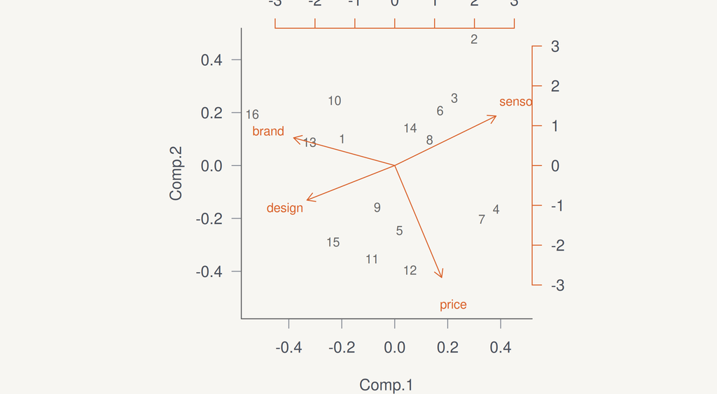

```r
biplot(pca, col = c("grey40", pal[2]), cex = 0.8)
```

Kaiser: keep components with an eigenvalue > 1. Comp.1 sets **taste** against **image** (brand, package).

## Factor analysis

```r
fa_data <- data.frame(
  quality = c(5,3,4,7,7,4,7,5,5,3,6,7,4,5,6,3), price = c(6,7,6,5,7,6,5,6,3,1,2,5,2,3,1,2),
  aesthetics = c(3,2,4,1,5,2,2,4,6,7,6,7,5,6,5,7), brand = c(4,2,5,3,5,3,1,4,7,5,7,6,6,5,5,7),
  friend = c(7,2,5,6,2,4,1,7,3,2,6,7,6,2,4,5), family = c(6,3,4,7,1,5,4,5,4,4,5,7,2,3,5,6))
round(eigen(cor(fa_data))$values, 2)
```

```
[1] 2.46 1.69 0.89 0.61 0.27 0.08
```

```r
print(factanal(fa_data, factors = 2)$loadings, cutoff = 0.4)
```

```
Loadings:
           Factor1 Factor2
quality
price      -0.657
aesthetics  0.933
brand       0.928
friend              0.992
family              0.620

               Factor1 Factor2
SS loadings      2.207   1.453
Proportion Var   0.368   0.242
Cumulative Var   0.368   0.610
```

## Cluster analysis: dendrogram

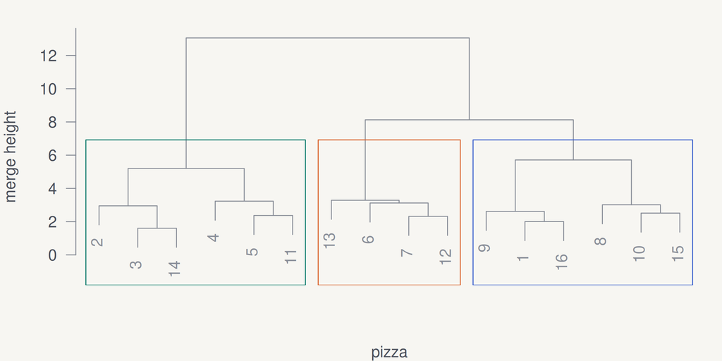

```r
fit <- hclust(dist(sensory), method = "ward.D")
plot(fit, main = "", xlab = "pizza", sub = "", ylab = "merge height")
rect.hclust(fit, k = 3, border = pal[1:3])
```

Similarity is given by the **merge height**, not by how close the labels are on the x-axis.

## k-means

```r
set.seed(1)
k3 <- kmeans(scale(sensory), centers = 3, nstart = 25)
k3$size
```

```
[1] 8 4 4
```

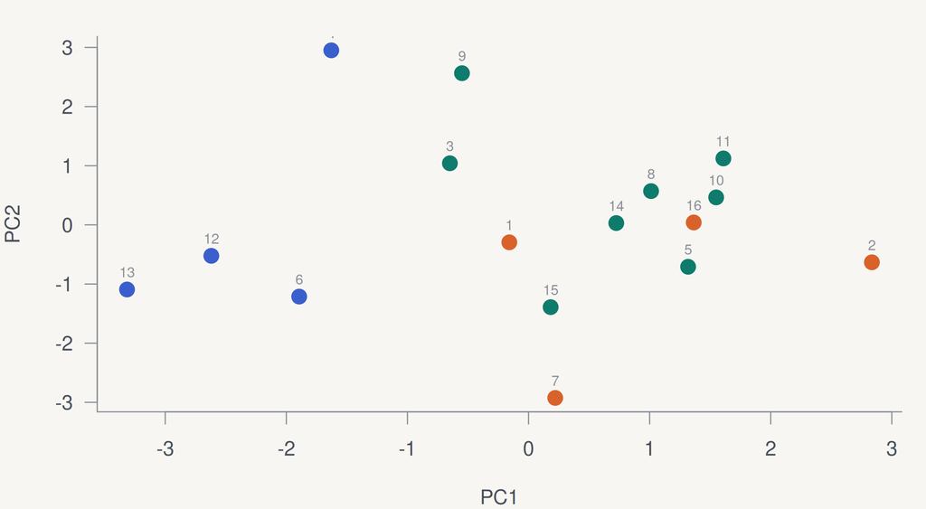

```r
pc <- prcomp(sensory, scale. = TRUE)$x
plot(pc[, 1:2], pch = 19, cex = 1.6,
     col = pal[k3$cluster])
text(pc[, 1:2], labels = 1:16, pos = 3, cex = 0.7)
```

`nstart = 25` – the algorithm runs 25 times and keeps the best solution. Optimal k: `fviz_nbclust(..., method = "silhouette")`.

## QUIZ Hierarchical or k-means?

You have 16 products and want to find out **how many** natural groups the market has. Which method do you start with?

**Hierarchical clustering** – the dendrogram shows the whole structure and you choose the number of groups afterwards. k-means needs the number of clusters in advance.

## Correspondence analysis

```r
age <- matrix(
  c(15, 2, 8, 7, 14, 4, 5, 5, 15, 11, 5, 9),
  ncol = 3, byrow = TRUE,
  dimnames = list(
    c("Men", "Women", "Children", "Seniors"),
    c("A", "B", "C")))
age
```

```
          A  B  C
Men      15  2  8
Women     7 14  4
Children  5  5 15
Seniors  11  5  9
```

```r
chisq.test(age)$p.value
```

```
[1] 0.0002687131
```

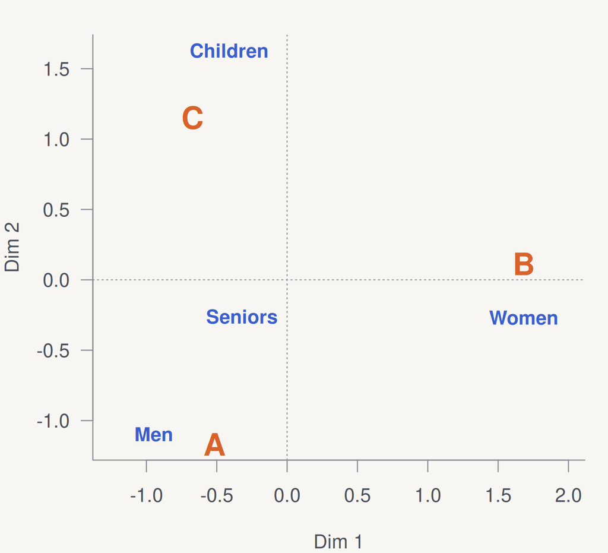

A category in the same **direction from the centre** as a product chooses it more often than chance would suggest.

## Summary

| question | method |
| --- | --- |
| are two attributes related? | correlation (Spearman), regression |
| which attributes go together? | PCA, factor analysis |
| which products are similar? | cluster analysis |
| which group chooses which product? | correspondence analysis |

Theory 6 Theory 7 Theory 8 Theory 9